# Likelihood Jon Gruden finishes his 10-year Raiders contract

Guy Spurrier

2018-01-09

At 3 p.m. today, the Oakland Raiders will hold a press conference to introduce Jon Gruden as their next head coach. The most interesting part of the deal isn’t that Gruden finally chose to leave ESPN’s Monday Night Football booth after nine years but that the Raiders were willing to make an unprecedented contract offer to entice him: 10 years and US$100 million reportedly. Almost everyone who has voiced an opinion about the length and heft of the deal have been incredulous.

It seemed worth investigating how likely it is he could finish the whole 10 years. There have certainly been a few decades-long head coaching tenures in the NFL, but they are rare. How often has one head coach lasted 10 or more years with one team in one continuous stretch?

Below is a histogram showing the number and the percentage of head coaches broken into two-year increments, regardless of the number of teams he’s worked for. The first bar shows the head coaches who have been the sideline boss for a total of 1-2 years, then 3-4 years, 5-6 years, and so on up to George Halas’s 40 years with the Bears (of whom he also happened to be the owner).

```r
#Jon Gruden expected to sign a 10-year deal with Raiders on Tuesday. How many coaches actually last 10 seasons with the same team?

library(tidyverse)
library(lubridate)
library(stringr)
library(readr)
library(RColorBrewer)
library(janitor)
devtools::install_github("sfirke/janitor") # advanced github version with 2&3-level tabyls
nflCoaches <- read_csv("~/Documents/R/Data files/Football/NFLcoachesALL-csv.txt")
```

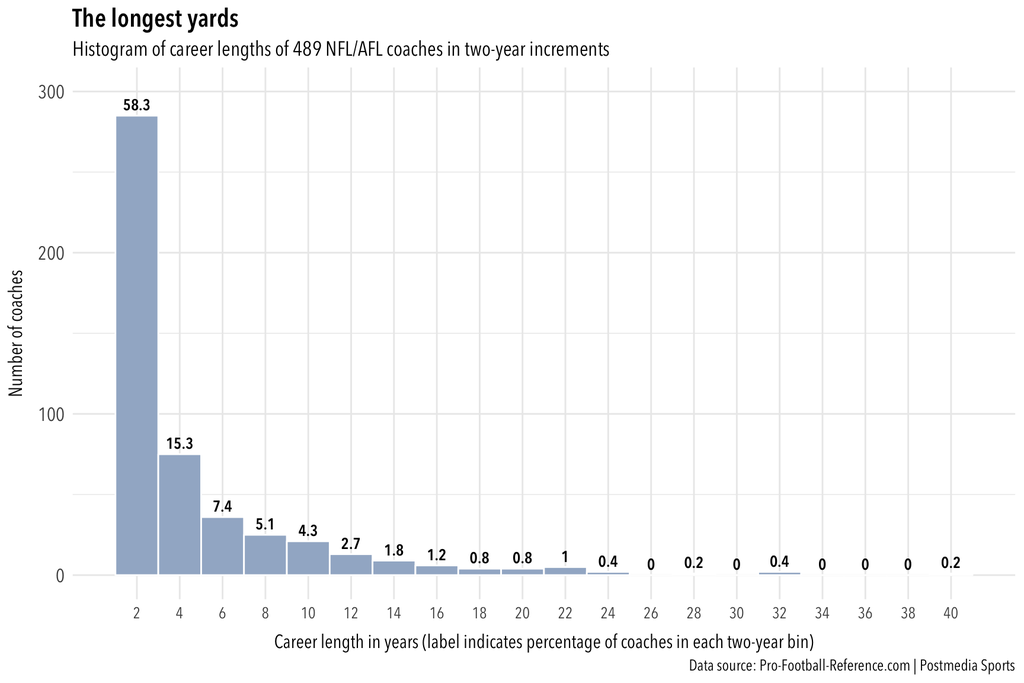

```r
nflTrim <- select(nflCoaches, c("Coach", "Years", "Yr-Yr", "G", "W", "L", "T", "W-L%"))

quartzFonts(ANXTC = c("Avenir Next Condensed Regular", "Avenir Next Condensed Demi Bold", "Avenir Next Condensed Italic", "Avenir Next Condensed Demi Bold Italic"))

ggplot(nflTrim, mapping = aes(Years)) +
  geom_histogram(binwidth = 2, colour = "white", fill = "lightsteelblue3") +
  theme_minimal() +
  theme(text = element_text(family = "ANXTC"), plot.title = element_text(size = 16, face = "bold"), plot.subtitle = element_text(size = 13, face = "plain"), axis.title.x = element_text(size = 12, face = "plain", margin = margin(t = 10)), axis.title.y = element_text(size = 12, face = "plain", margin = margin(r = 10)), axis.text.x = element_text(size = 10, face = "plain"), axis.text.y = element_text(size = 12, face = "plain")) +
  labs(title = "The longest yards", subtitle = "Histogram of career lengths of 489 NFL/AFL coaches in two-year increments", x = "Career length in years (label indicates percentage of coaches in each two-year bin)", y = "Number of coaches", caption = "Data source: Pro-Football-Reference.com | Postmedia Sports") +
  scale_x_continuous(breaks = c(2,4,6,8,10,12,14,16,18,20,22,24,26,28,30,32,34,36,38,40), minor_breaks = NULL) +
  ylim(0, 300) +
  stat_bin(geom = "text", aes(label = round(((..count.. / 489) * 100), 1), vjust = 0), binwidth = 2, vjust = -0.5, colour = "black", size = 3.5, family = "ANXTC", fontface = "bold")
```

Only 13.9 per cent of the 489 head coaches in the AFL and NFL have lasted 10 years or more. Gruden already has 11 years under his belt, four with the Raiders from 1998-2001 and seven with the Buccaneers from 2002-08. He’s already beaten those odds. To become a 20-year man, he would join a list of only 15 men that includes Don Shula and Curly Lambeau (33 years), Tom Landry (29 years), Bill Belichick (23 years and counting), and Chuck Noll and Dan Reeves (23 years). Andy Reid will hit 20 years next season.

Of the 68 head coaches who have had careers of 10 or more years, only 33 managed to have a tenure with one one team that lasted for 10 or more years. Below is a chart of those tenures, sort from earliest to most recent. Incredibly there are six coaches currently compiling one of these long-term assignments.

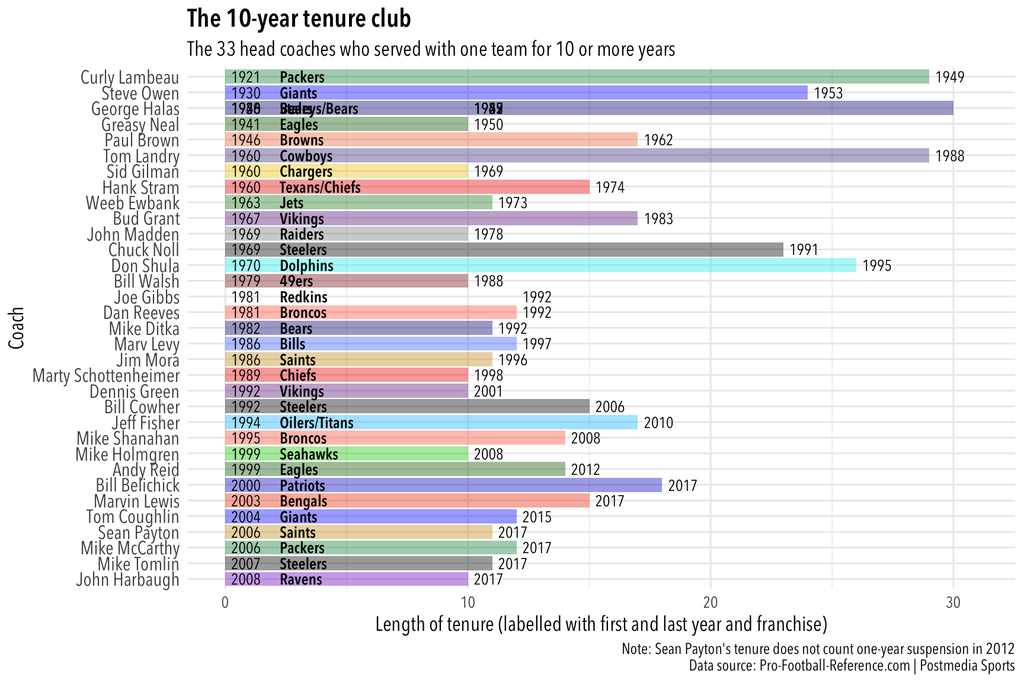

```r
##### horizontal bar chart for tenures of 10+ seasons

NFL10s <- read_csv("~/Documents/R/Data files/Football/NFLtenure-csv.txt")
ggplot(NFL10s) +
  geom_col(aes(x = reorder(Coach, -Start), y = Length, fill = Franchise, alpha = Franchise)) +
  coord_flip() +
  theme_minimal() +
  theme(text = element_text(family = "ANXTC"), plot.title = element_text(size = 16, face = "bold"), plot.subtitle = element_text(size = 13, face = "plain"), axis.title.x = element_text(size = 13, face = "plain"), axis.title.y = element_text(size = 13, face = "plain"), axis.text.x = element_text(size = 10, face = "plain"), axis.text.y = element_text(size = 12, face = "plain")) +
  labs(title = "The 10-year tenure club", subtitle = "The 33 head coaches who served with one team for 10 or more years", x = "Coach", y = "Length of tenure (labelled with first and last year and franchise)", caption = "Note: Sean Payton's tenure does not count one-year suspension in 2012\nData source: Pro-Football-Reference.com | Postmedia Sports") +
  ylim(0, 31) +
  annotate("text", x = NFL10s$Coach, y = 0.25, label = as.vector(NFL10s$Start), colour = "black", size = 3.5, hjust = 0, family = "ANXTC") +
  annotate("text", x = NFL10s$Coach, y = NFL10s$Length + 0.25, label = as.vector(NFL10s$Finish), colour = "black", size = 3.5, hjust = 0, family = "ANXTC") +
  annotate("text", x = NFL10s$Coach, y = 2.25, label = as.vector(NFL10s$Franchise), colour = "black", size = 3.5, hjust = 0, family = "ANXTC", fontface = "bold") +
  #scale_y_continuous(limits = c(1000, 1800), breaks = c(1000,1200,1400,1600,1800)) +
  #scale_y_continuous(breaks = c(50,100,150,200,250,300,350,400,450)) +
  scale_fill_manual(values = c("49ers"="firebrick4", "Bears"="navyblue", "Bengals"="orangered2", "Bills"="royalblue1", "Broncos"="tomato1", "Browns"="sienna2", "Chargers"="gold2", "Chiefs"="red2", "Cowboys"="darkslateblue", "Dolphins"="cyan2", "Eagles"="darkgreen", "Giants"="blue1", "Jets"="forestgreen", "Oilers/Titans"="deepskyblue1", "Packers"="springgreen4", "Patriots"="mediumblue", "Raiders"="snow4", "Ravens"="purple3", "Washington"="indianred4", "Saints"="goldenrod3", "Seahawks"="green3", "Staleys/Bears"="navyblue", "Steelers"="black", "Texans/Chiefs"="red2", "Vikings"="darkorchid4"
), guide = FALSE) +
  scale_alpha_manual(values = rep.int(0.4, 25), guide = FALSE)
```

We’re including the Saints’ Sean Payton, even though his tenure is bisected by his 2012 suspension from the Bountygate investigation. We won’t credit him for the year he sat our but we’ll give him credit for an unbroken term of employment.

It’s interesting that Halas was head coach for 40 seasons but that they came in four 10-year increments. He was a owner-player-coach in the first segment, and he returned the bench for the second instalment to save money during the Depression. His third stint came after he served in the Navy. His fourth period lasted until the beginning of the Super Bowl era.

Finally, let’s look at the Raiders history, with a chart that shows their wins each season, labels the three Super Bowl-winning seasons and marks the four periods in which the head coach lasted at least as long as Gruden’s first four-year tenure.

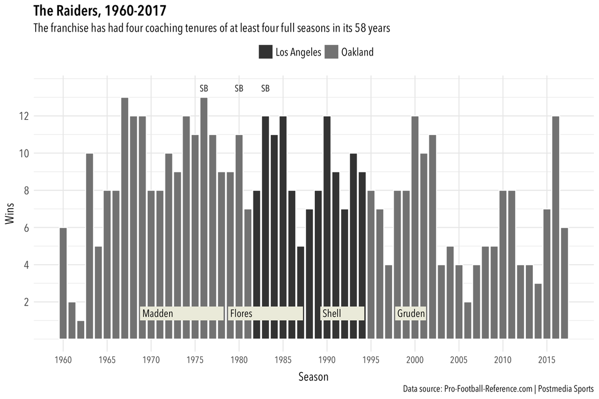

```r
##### bar chart for Raiders coaching

RaidersCoaches <- read_csv("~/Documents/R/Data files/Football/RaidersCoaches.csv")
ggplot(RaidersCoaches) +
  geom_col(aes(x = Year, y = Wins, fill = Location), colour = "white") +
  theme_minimal() +
  theme(text = element_text(family = "ANXTC"), plot.title = element_text(size = 16, face = "bold"), plot.subtitle = element_text(size = 13, face = "plain"), axis.title.x = element_text(size = 13, face = "plain", margin = margin(t = 10)), axis.title.y = element_text(size = 13, face = "plain"), axis.text.x = element_text(size = 10, face = "plain"), axis.text.y = element_text(size = 12, face = "plain"), legend.direction = "horizontal", legend.position = "top", legend.title = element_text(size = 12, face = "plain"), legend.text = element_text(size = 12, face = "plain")) +
  labs(title = "The Raiders, 1960-2017", subtitle = "The franchise has had four coaching tenures of at least four full seasons in its 58 years", x = "Season", y = "Wins", caption = "Data source: Pro-Football-Reference.com | Postmedia Sports") +
  scale_fill_manual(values = c("Los Angeles" = "gray26", "Oakland" = "gray52"), name = NULL) +
  scale_x_continuous(breaks = c(1960, 1965, 1970, 1975, 1980, 1985, 1990, 1995, 2000, 2005, 2010, 2015), minor_breaks = NULL) +
  scale_y_continuous(breaks = c(2, 4, 6, 8, 10, 12)) +
  annotate("rect", xmin = 1968.75, xmax = 1978.25, ymin = 1, ymax = 1.75, fill = "ivory2") +
  annotate("rect", xmin = 1978.75, xmax = 1987.25, ymin = 1, ymax = 1.75, fill = "ivory2") +
  annotate("rect", xmin = 1989.25, xmax = 1994.25, ymin = 1, ymax = 1.75, fill = "ivory2") +
  annotate("rect", xmin = 1997.75, xmax = 2001.25, ymin = 1, ymax = 1.75, fill = "ivory2") +
  #annotate("rect", xmin = 2014.75, xmax = 2017.25, ymin = 1, ymax = 1.75, fill = "ivory2") +
  annotate("text", x = c(1969, 1979, 1989.5, 1998), y = c(1.4, 1.4, 1.4, 1.4), label = c("Madden", "Flores", "Shell", "Gruden"), colour = "black", size = 4, hjust = 0, family = "ANXTC") +
  annotate("text", x = c(1976, 1980, 1983), y = c(13.5, 13.5, 13.5), label = c("SB", "SB", "SB"), colour = "black", size = 3.5, hjust = 0.5, family = "ANXTC")
```

John Madden and Tom Flores are easily the two most successful coaches in team history, which spans 21 head coaches. The Raiders have only been to the playoffs twice since Gruden was traded by Al Davis to Tampa Bay before the 2002 season for four draft picks and $8 million. Oakland, under Bill Callahan, lost the Super Bowl XXXVII to Gruden and the Buccaneers that first season after the trade. After a 13-year drought, the Raiders were a wild-card team in 2016 under Jack Del Rio.

Now Gruden has been given a long horizon to return to Raiders to their glory of the late ’70s and early ’80s.